# era

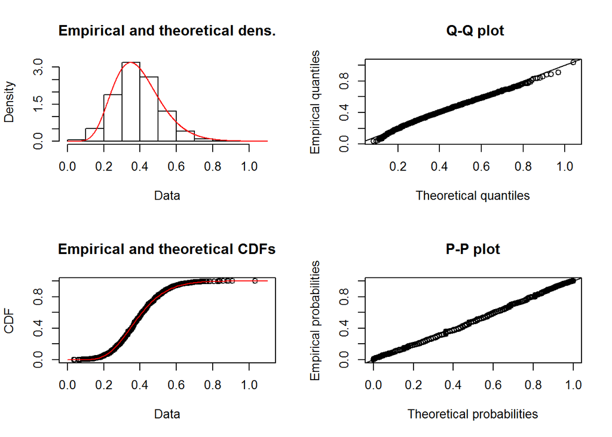

```r
prior_df[prior_df$wh_per_out == 0, 'wh_per_out'] <- 0.0366/ 2

library(fitdistrplus)
fit <- fitdist(prior_df$wh_per_out, "gamma")
plot(fit)
```

now we want to simulate draws from our data:

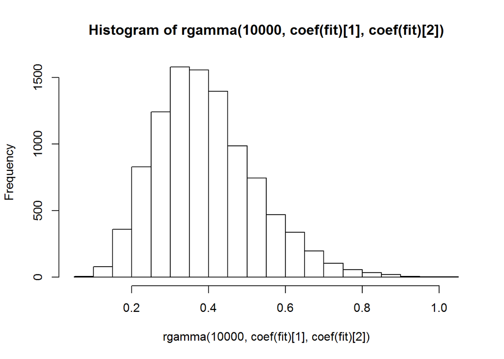

```r
hist(rgamma(10000, coef(fit)[1], coef(fit)[2]))
```

ok, so that’s our prior for true wh per out.

build generative model:

rather than try to simulate the oddly shaped IP distribution (some weird mixture of gaussians?), we’ll just take random draws from the ~6700 observed values.

```r
valid_ip <- ip_df %>% dplyr::filter(IP > 0)

wh_sim <- replicate(1000000, {
  sim_wh_per_out <- rgamma(1, coef(fit)[1], coef(fit)[2])
  sim_true_whip <- sim_wh_per_out * 3
  sim_outs_recorded <- round(sample_n(valid_ip, 1)$IP * 3, 0)

  sim_wh <- rpois(sim_outs_recorded, sim_wh_per_out)
  reported_whip <- (sum(sim_wh) / sim_outs_recorded) * 3

  c(true_whip = sim_true_whip, IP = sim_outs_recorded / 3, reported_whip = reported_whip)
})
wh_sim <- t(wh_sim)
head(wh_sim)
```

```
##      true_whip        IP reported_whip
## [1,] 1.9320712  4.000000     3.0000000
## [2,] 0.4659714  6.333333     0.3157895
## [3,] 0.5820973 10.666667     0.5625000
## [4,] 1.5126993  8.000000     1.6250000
## [5,] 1.1230646  3.000000     0.6666667
## [6,] 0.5436873 16.333333     0.6122449
```

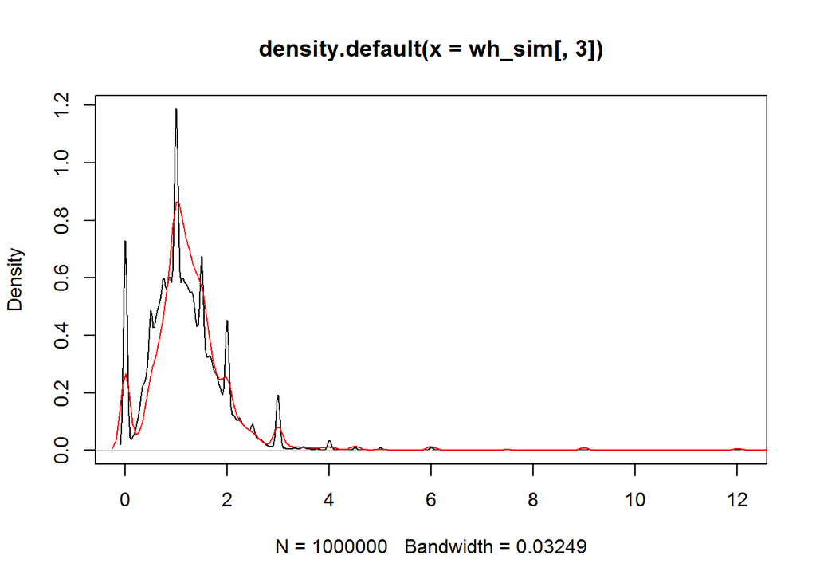

```r
p_sim <- density(wh_sim[, 3])
plot(p_sim)

p_true <- density(valid_ip$WHIP)
lines(p_true, col='red', new = FALSE)
```

now let’s look at some real data and see how the simulation can help infer the true rates behind the noisy data.

```r
wh_sim <- wh_sim %>% as.data.frame()

true_WHIP_est <- function(ip_in, reported_WHIP_in) {

  if(is.na(ip_in)) {
    return(NA)
  }

  wh_sim$rate_diff <- abs(wh_sim$reported_whip - reported_WHIP_in)
  wh_sim$ip_diff <- abs(round(wh_sim$IP, 1) - round(ip_in, 1))
  wh_sim$total_diff <- wh_sim$rate_diff + wh_sim$ip_diff
  wh_sim$rank <- rank(wh_sim$total_diff, ties.method = 'random')

  num_exact <- nrow(wh_sim[wh_sim$ip_diff == 0 & wh_sim$rate_diff < 0.1, ])
  if (num_exact > .0005 * nrow(wh_sim)) {
    true_mean <- mean(wh_sim[wh_sim$ip_diff == 0 & wh_sim$rate_diff < 0.1, ]$true_whip)
  } else {
    true_mean <- mean(wh_sim[wh_sim$rank <= .0005 * nrow(wh_sim), ]$true_whip, na.rm=TRUE)
  }

  return(round(true_mean, 2))
}
```